> **Lectura cómoda y navegación completa (recomendado)**  
> Informe web (HTML):  
> https://crgalleguillos.github.io/prediccion-precios-vuelos/

> Nota: GitHub puede no respetar correctamente la navegación interna en archivos `.ipynb`.  
> El informe web está pensado como la versión principal de lectura.

# Predicción de precio de vuelos (Economy & Business)

**Autor**: Cristián Andrés Galleguillos Vega  
**Objetivo** : Construir y evaluar modelos para predecir el precio de vuelos en segmentos **Economy** y **Business**.

## Mapa del notebook

1. Contexto y objetivo
2. Datos y preparación
3. EDA (univariado y bivariado)
4. Ingeniería de características
5. Modelado y validación
6. Resultados
7. Conclusiones y próximos pasos
8. Créditos y tecnologías utilizadas

## 1. Contexto y objetivo

La estimación de precios de vuelos es una tarea clave para la toma de decisiones en **pricing** y planificación comercial.  
En este trabajo abordamos la **predicción del precio** en dos segmentos de interés: **Economy** y **Business**.

**Objetivo principal:** Entrenar y comparar modelos de ML que predigan el precio final del vuelo, cuantificando el error y evaluando la estabilidad del desempeño.

**Valor para negocio:** Permite entender qué variables explican el precio y apoyar estrategias de **pricing dinámico** y monitoreo de mercado.

## 2. Datos y preparación

**Fuentes de datos:** Archivos `business.xlsx` y `economy.xlsx` proporcionados en el desafío.  
**Estructura:** Cada archivo contiene información detallada del vuelo (origen, destino, aerolínea, duración, escalas, etc.) y la variable objetivo `price`.

**Pasos realizados:**

1. Revisión de valores nulos y duplicados.
2. Detección y corrección de outliers mediante **IQR capping**.
3. Conversión de `duration` a minutos totales.
4. Codificación de variables categóricas (One-Hot Encoding).
5. División de los conjuntos en **train/test** con `random_state=123`.

## 3. EDA – Exploratory Data Analysis

En esta etapa realizamos un **análisis exploratorio de datos (EDA)** para comprender la estructura, distribución y relaciones entre las variables del conjunto de datos.  
El EDA nos permite detectar valores atípicos, correlaciones, y diferencias entre los segmentos **Economy** y **Business**, antes de aplicar modelos predictivos.

**Objetivos del EDA:**

1. Evaluar la calidad de los datos (nulos, duplicados, outliers).
2. Explorar la distribución de las variables numéricas.
3. Analizar las relaciones entre variables relevantes y el precio.
4. Identificar patrones distintos por segmento.

### 3.1 Revisión inicial de los datasets

```python
import os
print(os.listdir('../data'))
```

```
['.gitkeep', 'business.xlsx', 'economy.xlsx', 'get_data.py']
```

```python
# LIBRERÍAS PRINCIPALES

# Análisis y manipulación de datos
import pandas as pd
import numpy as np
import re

# Visualización
import matplotlib.pyplot as plt
import seaborn as sns

# Modelado y evaluación
from sklearn.model_selection import train_test_split
from sklearn.preprocessing import MinMaxScaler
from sklearn.linear_model import Ridge
from sklearn.ensemble import RandomForestRegressor, GradientBoostingRegressor
from sklearn.metrics import mean_absolute_error, mean_squared_error, r2_score

# Configuración general
import warnings
warnings.filterwarnings('ignore')
```

```python
# Cargar datos

econ = pd.read_excel('../data/economy.xlsx')
bus  = pd.read_excel('../data/business.xlsx')

# Mostrar estructura básica
print("Economy:", econ.shape, "filas x columnas")
print("Business:", bus.shape, "filas x columnas")

# Primeras filas
display(econ.head(5))
display(bus.head(5))

# Tipos de datos
print("\nTipos de datos – Economy")
display(econ.dtypes)
```

```
Economy: (206774, 11) filas x columnas
Business: (93487, 11) filas x columnas
```

|  | date | airline | ch_code | num_code | dep_time | from | time_taken | stop | arr_time | to | price |
| --- | --- | --- | --- | --- | --- | --- | --- | --- | --- | --- | --- |
| 0 | 2022-02-11 | SpiceJet | SG | 8709 | 18:55:00 | Delhi | 02h 10m | non-stop | 21:05:00 | Mumbai | 5953 |
| 1 | 2022-02-11 | SpiceJet | SG | 8157 | 06:20:00 | Delhi | 02h 20m | non-stop | 08:40:00 | Mumbai | 5953 |
| 2 | 2022-02-11 | AirAsia | I5 | 764 | 04:25:00 | Delhi | 02h 10m | non-stop | 06:35:00 | Mumbai | 5956 |
| 3 | 2022-02-11 | Vistara | UK | 995 | 10:20:00 | Delhi | 02h 15m | non-stop | 12:35:00 | Mumbai | 5955 |
| 4 | 2022-02-11 | Vistara | UK | 963 | 08:50:00 | Delhi | 02h 20m | non-stop | 11:10:00 | Mumbai | 5955 |

|  | date | airline | ch_code | num_code | dep_time | from | time_taken | stop | arr_time | to | price |
| --- | --- | --- | --- | --- | --- | --- | --- | --- | --- | --- | --- |
| 0 | 2022-02-11 | Air India | AI | 868 | 18:00:00 | Delhi | 02h 00m | non-stop | 20:00:00 | Mumbai | 25612 |
| 1 | 2022-02-11 | Air India | AI | 624 | 19:00:00 | Delhi | 02h 15m | non-stop | 21:15:00 | Mumbai | 25612 |
| 2 | 2022-02-11 | Air India | AI | 531 | 20:00:00 | Delhi | 24h 45m | 1-stop\n\t\t\t\t\t\t\t\t\t\t\t\t\n\t\t\t\t\t\t... | 20:45:00 | Mumbai | 42220 |
| 3 | 2022-02-11 | Air India | AI | 839 | 21:25:00 | Delhi | 26h 30m | 1-stop\n\t\t\t\t\t\t\t\t\t\t\t\t\n\t\t\t\t\t\t... | 23:55:00 | Mumbai | 44450 |
| 4 | 2022-02-11 | Air India | AI | 544 | 17:15:00 | Delhi | 06h 40m | 1-stop\n\t\t\t\t\t\t\t\t\t\t\t\t\n\t\t\t\t\t\t... | 23:55:00 | Mumbai | 46690 |

```
Tipos de datos – Economy
```

```
date          datetime64[ns]
airline               object
ch_code               object
num_code               int64
dep_time              object
from                  object
time_taken            object
stop                  object
arr_time              object
to                    object
price                  int64
dtype: object
```

#### Calidad de datos: nulos y duplicados

```python
# Porcentaje de nulos
nulls_econ = econ.isna().mean() * 100
nulls_bus = bus.isna().mean() * 100

print("Nulos en Economy:")
display(nulls_econ[nulls_econ > 0].sort_values(ascending=False))

print("\nNulos en Business:")
display(nulls_bus[nulls_bus > 0].sort_values(ascending=False))

# Duplicados
dup_econ = econ.duplicated().sum()
dup_bus = bus.duplicated().sum()

print(f"\nDuplicados – Economy: {dup_econ} | Business: {dup_bus}")
```

```
Nulos en Economy:
```

```
Series([], dtype: float64)
```

```
Nulos en Business:
```

```
Series([], dtype: float64)
```

```
Duplicados – Economy: 2 | Business: 0
```

```python
# Eliminar duplicados del dataset Economy
econ = econ.drop_duplicates().reset_index(drop=True)
print(f"Economy después de eliminar duplicados: {econ.shape}")
```

```
Economy después de eliminar duplicados: (206772, 11)
```

#### **Observaciones**

**Resultados:**

- No se encontraron valores nulos en ninguna de las columnas, tanto en **Economy** como en **Business**.
- Se detectaron **2 registros duplicados** en el dataset de Economy y **0 duplicados** en Business.
- El dataset final de *Economy* pasó de **206 774 a 206 772 filas**, mientras que *Business* se mantuvo en **93 487 filas**.

**Acción tomada:**

- Los duplicados del conjunto Economy fueron eliminados para mantener la integridad de los datos.

**Conclusión:**

- Los datos presentan una muy buena calidad incicial, sin valores faltantes ni inconsistencias graves.
- Esto permite avanzar directamente al análisis exploratorio y a la transformación de variables sin necesidad de imputación.

### 3.2 Distribución de variables numéricas

Analizamos la distribución de las variables numéricas clave:

- **`price`**, para observar la dispersión y la asimetría de los precios en cada segmento.
- **`duration_mins`**, para entender la distribución de duraciones de vuelo en minutos.

Esto permitirá identificar **sesgos, colas largas y valores extremos** antes de realizar el tratamiento de outliers.

#### Preparación y limpieza

```python
# 1) Asegurar `price` numérico (maneja comas tipo "1,14,434", espacios u otros símbolos)
def clean_price(series: pd.Series) -> pd.Series:
    s = series.astype(str).str.strip()
    # Eliminar todo lo no numérico (soporta formatos con comas "indias")
    s = s.str.replace(r'[^0-9]', '', regex=True)
    # Vacíos -> NA; usar Int64 para tolerar NA mientras limpiamos
    s = s.replace('', pd.NA).astype('Int64')
    return s

econ['price'] = clean_price(econ['price'])
bus['price']  = clean_price(bus['price'])

# Eliminar filas con price NA
before_e, before_b = len(econ), len(bus)
econ = econ.dropna(subset=['price']).reset_index(drop=True)
bus  = bus.dropna(subset=['price']).reset_index(drop=True)
print(f"[Economy] filas: {before_e} -> {len(econ)} (tras normalizar 'price')")
print(f"[Business] filas: {before_b} -> {len(bus)} (tras normalizar 'price')")

# Cast final a int (ya sin NA)
econ['price'] = econ['price'].astype(int)
bus['price']  = bus['price'].astype(int)

# 2) Convertir `time_taken` -> minutos totales en `duration_mins`
def to_minutes(duration_str):
    if isinstance(duration_str, str):
        hours = re.findall(r'(\d+)h', duration_str)
        mins  = re.findall(r'(\d+)m', duration_str)
        h = int(hours[0]) if hours else 0
        m = int(mins[0])  if mins  else 0
        return h * 60 + m
    return pd.NA

econ['duration_mins'] = econ['time_taken'].apply(to_minutes).astype('Int64')
bus['duration_mins']  = bus['time_taken'].apply(to_minutes).astype('Int64')

print("Tipos (price, duration_mins) →",
      econ['price'].dtype, econ['duration_mins'].dtype,
      "|", bus['price'].dtype, bus['duration_mins'].dtype)
```

```
[Economy] filas: 206772 -> 206772 (tras normalizar 'price')
[Business] filas: 93487 -> 93487 (tras normalizar 'price')
Tipos (price, duration_mins) → int32 Int64 | int32 Int64
```

#### Histogramas de price por segmento

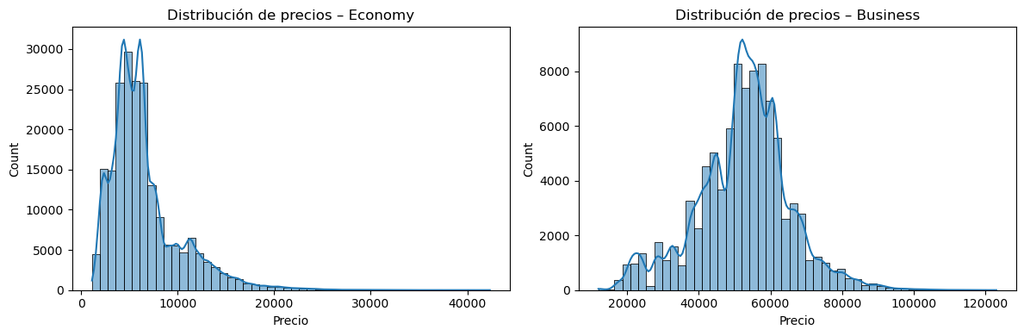

```python
fig, axes = plt.subplots(1, 2, figsize=(12, 4))

sns.histplot(econ['price'].dropna(), bins=50, kde=True, ax=axes[0])
axes[0].set_title('Distribución de precios – Economy')
axes[0].set_xlabel('Precio')

sns.histplot(bus['price'].dropna(), bins=50, kde=True, ax=axes[1])
axes[1].set_title('Distribución de precios – Business')
axes[1].set_xlabel('Precio')

plt.tight_layout()
plt.show()
```

#### Histogramas de duration_mins por segmento

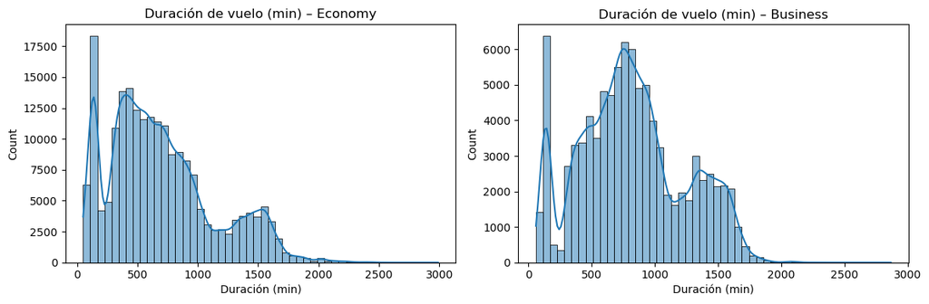

```python
fig, axes = plt.subplots(1, 2, figsize=(12, 4))

sns.histplot(econ['duration_mins'].dropna(), bins=50, kde=True, ax=axes[0])
axes[0].set_title('Duración de vuelo (min) – Economy')
axes[0].set_xlabel('Duración (min)')

sns.histplot(bus['duration_mins'].dropna(), bins=50, kde=True, ax=axes[1])
axes[1].set_title('Duración de vuelo (min) – Business')
axes[1].set_xlabel('Duración (min)')

plt.tight_layout()
plt.show()
```

#### Boxplots para detección visual de outliers

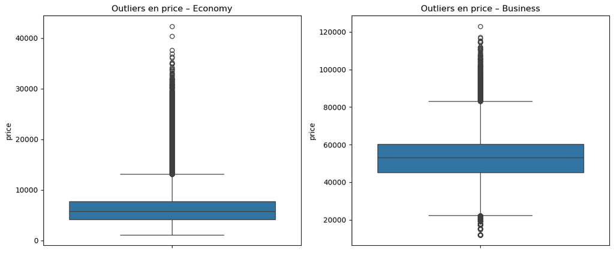

```python
fig, axes = plt.subplots(1, 2, figsize=(12, 5))

sns.boxplot(y=econ['price'].dropna(), ax=axes[0])
axes[0].set_title('Outliers en price – Economy')

sns.boxplot(y=bus['price'].dropna(), ax=axes[1])
axes[1].set_title('Outliers en price – Business')

plt.tight_layout()
plt.show()
```

#### **Observaciones del análisis numérico**

**Distribución de precios (price)**

- En el segmento Economy, los precios se concentran principalmente entre 3 000 y 10 000 unidades, con una cola larga hacia la derecha, lo que indica la existencia de vuelos con precios significativamente más altos.  
  Se aprecian varios picos locales (modas), probablemente relacionados con diferentes aerolíneas o tipos de ruta.
- En el segmento Business, la distribución es más amplia y centrada alrededor de 50 000–60 000 unidades.  
  También presenta asimetría positiva, pero con una dispersión mucho mayor, reflejando una oferta más heterogénea en precios según servicio o clase del vuelo.
- Ambos histogramas confirman que price no sigue una distribución normal, y que será necesario aplicar técnicas de escalado o capping de outliers antes del modelado.

**Boxplots de price**

- Los boxplots refuerzan la asimetría observada:

En Economy, la mayoría de los valores se agrupan por debajo de 10 000, con numerosos outliers positivos que superan los 30 000.

En Business, la mediana se ubica cerca de 55 000, con valores extremos que llegan incluso a 120 000.

- Este comportamiento sugiere que los precios altos podrían deberse a combinaciones específicas de aerolínea, escalas y horarios que elevan el costo.

#### **Conclusión**

Ambas variables (price y duration_mins) presentan distribuciones asimétricas y presencia de outliers.

Este patrón es común en datos de vuelos y no indica error, pero sí requiere un tratamiento estadístico controlado.

En el siguiente paso se aplicará IQR capping (winsorización) para mitigar el impacto de valores extremos sin eliminar observaciones.

### 3.3 Tratamiento de outliers (IQR Capping)

#### Objetivo

Los outliers detectados en price y duration_mins pueden afectar el rendimiento de los modelos de Machine Learning, especialmente en regresión.  
Aplicaremos el método Interquartile Range (IQR) para limitar los valores extremos dentro de un rango estadísticamente razonable, sin eliminar observaciones.

```python
# Función de winsorización por IQR

def iqr_capping(df, column, multiplier=1.5):
    """
    Aplica winsorización por IQR.
    Limita los valores por debajo de (Q1 - 1.5*IQR)
    y por encima de (Q3 + 1.5*IQR).
    Retorna el DataFrame modificado y los límites.
    """
    Q1 = df[column].quantile(0.25)
    Q3 = df[column].quantile(0.75)
    IQR = Q3 - Q1
    lower = Q1 - multiplier * IQR
    upper = Q3 + multiplier * IQR
    capped = df[column].clip(lower, upper)
    print(f"{column}: Rango IQR [{lower:.2f}, {upper:.2f}]")
    print(f"Valores recortados: {(df[column] != capped).sum()}")
    df[column] = capped
    return df, lower, upper

# Aplicar a ambas variables en ambos segmentos
econ, l1, u1 = iqr_capping(econ, 'price')
bus,  l2, u2 = iqr_capping(bus,  'price')
econ, l3, u3 = iqr_capping(econ, 'duration_mins')
bus,  l4, u4 = iqr_capping(bus,  'duration_mins')
```

```
price: Rango IQR [-1186.50, 13105.50]
Valores recortados: 13750
price: Rango IQR [22368.50, 83212.50]
Valores recortados: 3650
duration_mins: Rango IQR [-435.00, 1725.00]
Valores recortados: 2652
duration_mins: Rango IQR [-280.00, 1880.00]
Valores recortados: 90
```

### Tratamiento de outliers (IQR capping)

#### Resultados

- **Economy – `price`:** rango IQR aplicado **[-1 186.5, 13 105.5]**, por lo tanto **13 750 valores recortados** (≈ 6.6%).
- **Business – `price`:** rango IQR aplicado **[22 368.5, 83 212.5]**, por lo tanto **3 650 valores recortados** (≈ 3.9%).
- **Economy – `duration_mins`:** rango IQR aplicado **[-435, 1 725]** min, por lo tanto **2 652 registros ajustados**.
- **Business – `duration_mins`:** rango IQR aplicado **[-280, 1 880]** min, por lo tanto **90 registros ajustados**.

> Nota: los límites inferiores negativos se corrigen con `clip()` y quedan truncados al mínimo real (> 0).

#### Visualización antes y después

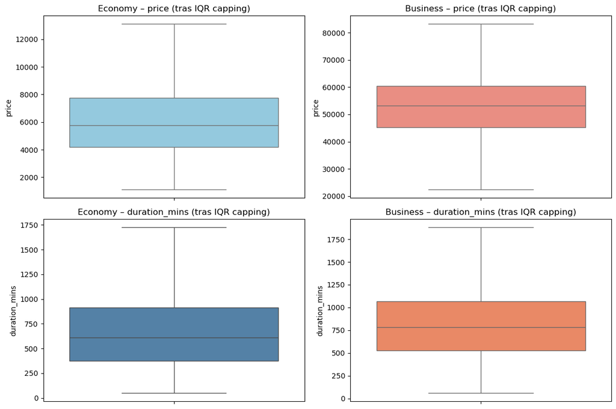

```python
fig, axes = plt.subplots(2, 2, figsize=(12, 8))

sns.boxplot(y=econ['price'], ax=axes[0,0], color='skyblue')
axes[0,0].set_title('Economy – price (tras IQR capping)')

sns.boxplot(y=bus['price'], ax=axes[0,1], color='salmon')
axes[0,1].set_title('Business – price (tras IQR capping)')

sns.boxplot(y=econ['duration_mins'], ax=axes[1,0], color='steelblue')
axes[1,0].set_title('Economy – duration_mins (tras IQR capping)')

sns.boxplot(y=bus['duration_mins'], ax=axes[1,1], color='coral')
axes[1,1].set_title('Business – duration_mins (tras IQR capping)')

plt.tight_layout()
plt.show()
```

#### Interpretación de los boxplots

- Tras el capping, las distribuciones quedan **más compactas y simétricas**, sin outliers visibles.
- **Economy (`price`)** conserva mediana ~**6 000**, señal de que los ajustes afectaron sobre todo valores marginales.
- **Business (`price`)** mantiene mediana ~**55 000**, con dispersión controlada tras eliminar extremos (> 100 000).
- **`duration_mins`** queda estabilizada principalmente entre **~300 y 1 500 min**, coherente con tramos nacionales/internacionales.

#### Conclusión

- El **IQR capping** redujo el impacto de valores atípicos **sin eliminar observaciones**, preservando la integridad del dataset.
- Las variables quedan **más robustas para el modelado** (menor sensibilidad a extremos en regresión/boosting).
- `price` y `duration_mins` están **listas para el análisis bivariado** y la etapa de modelado.

### 3.4 Análisis bivariado

#### Objetivo

Explorar las relaciones entre price (variable objetivo) y otras variables del dataset, para identificar patrones y factores que influyen en el precio de los vuelos.

Se analizan:

- Relaciones numéricas (duration_mins vs price) mediante correlación y dispersión.
- Relaciones categóricas (stop, airline, from, to) mediante boxplots comparativos.

#### Correlación entre variables numéricas

```python
# Calcular correlaciones para variables numéricas
corr_econ = econ[['price', 'duration_mins']].corr()
corr_bus  = bus[['price', 'duration_mins']].corr()

print("Correlación Economy:")
display(corr_econ)

print("Correlación Business:")
display(corr_bus)
```

```
Correlación Economy:
```

|  | price | duration_mins |
| --- | --- | --- |
| price | 1.000000 | 0.313434 |
| duration_mins | 0.313434 | 1.000000 |

```
Correlación Business:
```

|  | price | duration_mins |
| --- | --- | --- |
| price | 1.000000 | 0.243108 |
| duration_mins | 0.243108 | 1.000000 |

### Correlación entre variables numéricas

| Segmento | Correlación `price` – `duration_mins` |
| --- | --- |
| Economy | **0.31** |
| Business | **0.24** |

#### Observaciones

- En ambos segmentos se observa una **correlación positiva**, es decir, los vuelos de mayor duración tienden a ser más costosos.
- La fuerza de la relación es **moderada en Economy (0.31)** y **más débil en Business (0.24)**.
- Esto sugiere que en *Business*, el precio depende también de otros factores (servicio, aerolínea, clase, horarios), mientras que en *Economy*, la duración del vuelo tiene un peso algo mayor.

#### Visualización: price vs duration_mins

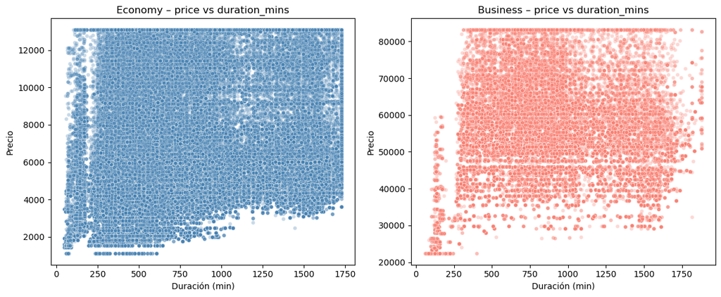

```python
fig, axes = plt.subplots(1, 2, figsize=(12, 5))

sns.scatterplot(data=econ, x='duration_mins', y='price', alpha=0.3, s=20, ax=axes[0], color='steelblue')
axes[0].set_title('Economy – price vs duration_mins')
axes[0].set_xlabel('Duración (min)')
axes[0].set_ylabel('Precio')

sns.scatterplot(data=bus, x='duration_mins', y='price', alpha=0.3, s=20, ax=axes[1], color='salmon')
axes[1].set_title('Business – price vs duration_mins')
axes[1].set_xlabel('Duración (min)')
axes[1].set_ylabel('Precio')

plt.tight_layout()
plt.show()
```

#### Observaciones

- En **Economy**, se aprecia una tendencia **ligeramente ascendente**, donde los vuelos de más de 1 000 minutos concentran precios más altos, aunque con dispersión creciente.
- En **Business**, la nube de puntos es más **dispersa**, lo que confirma que el precio no depende únicamente de la duración, sino también de la aerolínea y el tipo de vuelo.
- Ambos gráficos muestran una relación **no lineal**, lo que sugiere que en modelos predictivos podría ser útil aplicar transformaciones logarítmicas o polinomiales.

#### Limpieza de la variable stop

```python
def normalize_stop(s):
    if pd.isna(s):
        return pd.NA
    t = str(s).lower()
    t = re.sub(r'\s+', ' ', t).strip()
    t = t.replace('non stop', 'non-stop').replace('non-stop', '0-stop')
    m = re.search(r'(\d+)\s*[- ]*\s*stop', t)
    if '0-stop' in t:
        n = 0
    elif m:
        n = int(m.group(1))
    else:
        mplus = re.search(r'(\d+)\s*\+\s*stop', t)
        if mplus:
            n = int(mplus.group(1)) + 1
        else:
            return pd.NA
    if n == 0:
        return 'non-stop'
    elif n == 1:
        return '1-stop'
    else:
        return '2+-stops'

econ['stop_clean'] = econ['stop'].apply(normalize_stop)
bus['stop_clean']  = bus['stop'].apply(normalize_stop)

print(econ['stop_clean'].value_counts())
print(bus['stop_clean'].value_counts())
```

```
stop_clean
1-stop      166625
non-stop     27942
Name: count, dtype: int64
stop_clean
1-stop      84302
non-stop     8102
Name: count, dtype: int64
```

#### Price por número de escalas (boxplots limpios)

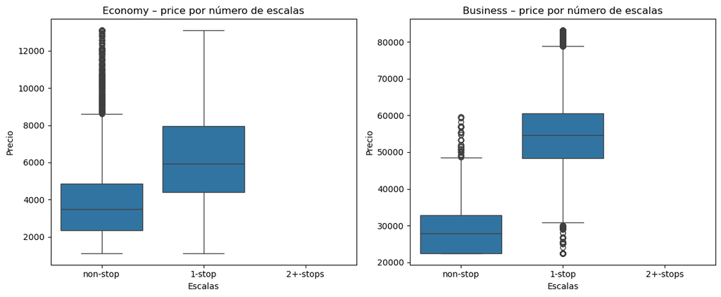

```python
order = ['non-stop', '1-stop', '2+-stops']

fig, axes = plt.subplots(1, 2, figsize=(12, 5))

sns.boxplot(
    x='stop_clean', y='price',
    data=econ.dropna(subset=['stop_clean']),
    order=order, ax=axes[0]
)
axes[0].set_title('Economy – price por número de escalas')
axes[0].set_xlabel('Escalas')
axes[0].set_ylabel('Precio')

sns.boxplot(
    x='stop_clean', y='price',
    data=bus.dropna(subset=['stop_clean']),
    order=order, ax=axes[1]
)
axes[1].set_title('Business – price por número de escalas')
axes[1].set_xlabel('Escalas')
axes[1].set_ylabel('Precio')

plt.tight_layout()
plt.show()
```

#### Observación: Precio según número de escalas (`stop_clean`)

[output not shown]

#### Precio promedio por aerolínea

```python
# Top 10 aerolíneas por precio promedio (segmento a segmento)
mean_price_econ = (
    econ.groupby('airline', dropna=False)['price']
        .mean()
        .sort_values(ascending=False)
        .head(10)
)
mean_price_bus = (
    bus.groupby('airline', dropna=False)['price']
       .mean()
       .sort_values(ascending=False)
       .head(10)
)

# Comprobación
display(mean_price_econ.to_frame('Precio promedio – Economy'))
display(mean_price_bus.to_frame('Precio promedio – Business'))
```

| airline | Precio promedio – Economy |
| --- | --- |
| Vistara | 7484.399829 |
| Air India | 7001.725559 |
| SpiceJet | 6046.644601 |
| GO FIRST | 5587.036027 |
| Indigo | 5206.398098 |
| StarAir | 4860.909836 |
| AirAsia | 4007.103305 |
| Trujet | 3244.634146 |

| airline | Precio promedio – Business |
| --- | --- |
| Vistara | 55373.605324 |
| Air India | 47195.887622 |

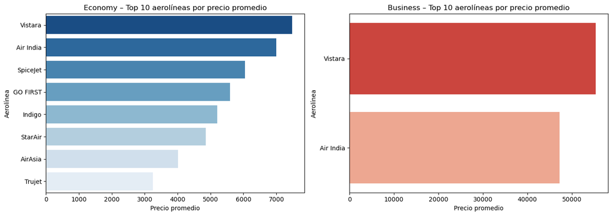

```python
fig, axes = plt.subplots(1, 2, figsize=(14, 5))

sns.barplot(
    x=mean_price_econ.values,
    y=mean_price_econ.index,
    hue=mean_price_econ.index,
    palette='Blues_r',
    legend=False,
    ax=axes[0]
)
axes[0].set_title('Economy – Top 10 aerolíneas por precio promedio')
axes[0].set_xlabel('Precio promedio')
axes[0].set_ylabel('Aerolínea')

sns.barplot(
    x=mean_price_bus.values,
    y=mean_price_bus.index,
    hue=mean_price_bus.index,
    palette='Reds_r',
    legend=False,
    ax=axes[1]
)
axes[1].set_title('Business – Top 10 aerolíneas por precio promedio')
axes[1].set_xlabel('Precio promedio')
axes[1].set_ylabel('Aerolínea')

plt.tight_layout()
plt.show()
```

#### Observaciones

- En **Economy**, destacan aerolíneas como **Vistara**, **Air India** y **SpiceJet**, que mantienen precios promedio superiores al resto.
- En **Business**, las mismas compañías lideran el ranking, pero con diferencias mucho mayores en el precio promedio.
- Las aerolíneas de bajo costo (p. ej. *Trujet*, *AirAsia*) presentan precios considerablemente inferiores, lo que refuerza su perfil de mercado.
- Este resultado sugiere que la variable `airline` podría ser un **predictor relevante** en los modelos de machine learning.

### Conclusión general del EDA

El análisis exploratorio permitió comprender la estructura, consistencia y relaciones más relevantes dentro de los datos de vuelos en los segmentos **Economy** y **Business**.

**Conclusión:** El EDA confirma que los datos están **limpios, estructurados y con relaciones interpretables** entre variables clave.  
Existen diferencias claras entre segmentos y aerolíneas, así como patrones de precios asociados a duración y número de escalas.

## 4. Ingeniería de características

### Objetivo

Optimizar la representación de las variables, generar nuevas características relevantes y preparar los conjuntos de datos para el modelado predictivo.  
El propósito es mejorar la capacidad de los modelos para capturar patrones en los datos sin introducir redundancia ni colinealidad.

### 4.1 Preprocesamiento de datos

#### Objetivo

Estandarizar y preparar los datos de entrada para el modelado predictivo, garantizando consistencia entre columnas, limpieza en los textos y generación de variables temporales que aporten valor al modelo.

El propósito es asegurar que las variables estén listas para ser interpretadas por los algoritmos de Machine Learning, eliminando fuentes de ruido o redundancia y mejorando la calidad de las representaciones.

### Limpieza y transformación de variables categóricas

**Tareas principales:**

1. **Renombrado de columnas:**  
   Se reemplazan nombres reservados o ambiguos (`from → origin`, `to → destination`) para evitar conflictos con palabras clave y mejorar la legibilidad del dataset.
2. **Eliminación de columnas irrelevantes:**  
   Se eliminan los campos de identificación (`ch_code`, `num_code`) que no aportan valor predictivo y podrían introducir ruido en el modelo.
3. **Normalización de categorías:**  
   La columna `stop` se limpia de caracteres residuales (saltos de línea, tabulaciones, espacios) y se unifica en una variable nueva `stop_clean`.  
   Esto permite diferenciar correctamente vuelos directos (`non-stop`), con una escala (`1-stop`) o múltiples escalas (`2+-stops`).
4. **Extracción de variables temporales:**  
   A partir de `date`, se derivan tres atributos:
   - `month`: captura la estacionalidad.
   - `day`: refleja posibles patrones diarios.
   - `weekday`: permite identificar comportamientos distintos entre días laborales y fines de semana.
5. **Limpieza profunda de texto:**  
   Se eliminan caracteres especiales y espacios innecesarios en todas las columnas de tipo texto, estandarizando los valores categóricos para su correcta codificación posterior.
6. **Eliminación de columnas crudas de tiempo:**  
   Se remueven las columnas originales (`date`, `dep_time`, `arr_time`, `time_taken`), ya que sus componentes relevantes ya fueron extraídos y convertidos en variables útiles para el modelado.

```python
# Copias limpias
econ_clean = econ.copy()
bus_clean  = bus.copy()

# Renombrar columnas
econ_clean = econ_clean.rename(columns={'from': 'origin', 'to': 'destination'})
bus_clean  = bus_clean.rename(columns={'from': 'origin', 'to': 'destination'})

# Eliminar columnas irrelevantes de identificador
econ_clean = econ_clean.drop(columns=['ch_code', 'num_code'])
bus_clean  = bus_clean.drop(columns=['ch_code', 'num_code'])

# Normalizar stops (conservar todas las categorías posibles)
econ_clean['stop_clean'] = econ_clean['stop'].astype(str).str.replace(r'[\n\t]+', ' ', regex=True).str.strip()
bus_clean['stop_clean']  = bus_clean['stop'].astype(str).str.replace(r'[\n\t]+', ' ', regex=True).str.strip()

# Extraer mes, día y día de la semana desde la fecha
econ_clean['month'] = pd.to_datetime(econ_clean['date'], errors='coerce').dt.month
econ_clean['day'] = pd.to_datetime(econ_clean['date'], errors='coerce').dt.day
econ_clean['weekday'] = pd.to_datetime(econ_clean['date'], errors='coerce').dt.weekday

bus_clean['month'] = pd.to_datetime(bus_clean['date'], errors='coerce').dt.month
bus_clean['day'] = pd.to_datetime(bus_clean['date'], errors='coerce').dt.day
bus_clean['weekday'] = pd.to_datetime(bus_clean['date'], errors='coerce').dt.weekday

# Remover columnas crudas de fecha/hora (ya no las necesitamos en X)
cols_time = ['date', 'dep_time', 'arr_time', 'time_taken']
econ_clean = econ_clean.drop(columns=[c for c in cols_time if c in econ_clean.columns])
bus_clean  = bus_clean.drop(columns=[c for c in cols_time if c in bus_clean.columns])

# Limpieza profunda de strings: elimina saltos de línea, tabs y espacios extras
def limpiar_texto(col):
    if col.dtype == 'object':
        return col.astype(str).str.replace(r'[\n\t]+', ' ', regex=True).str.strip()
    return col

econ_clean = econ_clean.apply(limpiar_texto)
bus_clean  = bus_clean.apply(limpiar_texto)
```

### 4.2 Codificación de variables categóricas

#### Objetivo

Transformar las variables categóricas en representaciones numéricas sin perder información ni interpretabilidad, permitiendo que los algoritmos puedan procesarlas correctamente.

#### Estrategia aplicada

Se utiliza **One-Hot Encoding (OHE)** sobre las variables categóricas principales:

- `airline` → Representa la aerolínea operadora del vuelo.
- `origin` y `destination` → Capturan el efecto de las rutas y aeropuertos en los precios.
- `stop_clean` → Indica la cantidad de escalas (factor clave en la tarifa final).

El OHE crea nuevas columnas binarias para cada categoría (por ejemplo, `airline_Indigo`, `destination_Mumbai`, etc.), asignando valores `1` o `0` según corresponda.  
De esta forma, los modelos numéricos pueden interpretar correctamente estas variables **sin imponer un orden artificial**, como ocurriría con un Label Encoding.

Las variables numéricas (`duration_mins`, `month`, `day`, `weekday`) se mantienen sin transformar en esta etapa, ya que se escalarán posteriormente.

```python
cat_vars_e = [c for c in ['airline','origin','destination','stop_clean'] if c in econ_clean.columns]
cat_vars_b = [c for c in ['airline','origin','destination','stop_clean'] if c in bus_clean.columns]

num_vars_e = [c for c in ['duration_mins','month','day','weekday'] if c in econ_clean.columns]
num_vars_b = [c for c in ['duration_mins','month','day','weekday'] if c in bus_clean.columns]

# OHE sin tocar las numéricas
X_econ = pd.concat([econ_clean[num_vars_e], pd.get_dummies(econ_clean[cat_vars_e], drop_first=True)], axis=1)
X_bus  = pd.concat([bus_clean[num_vars_b],  pd.get_dummies(bus_clean[cat_vars_b],  drop_first=True)], axis=1)

y_econ = econ_clean['price'].astype(int)
y_bus  = bus_clean['price'].astype(int)

print("Economy – X:", X_econ.shape, "| y:", y_econ.shape)
print("Business – X:", X_bus.shape,  "| y:", y_bus.shape)
```

```
Economy – X: (206772, 57) | y: (206772,)
Business – X: (93487, 39) | y: (93487,)
```

#### Observación:

El aumento del número de columnas refleja la creación de variables binarias a partir de las categorías originales.  
Esto es esperado: el dataset Economy, con más aerolíneas y rutas, genera 57 columnas tras la codificación, mientras que Business, con menos combinaciones, produce 39.

### 4.3 Escalado de variables numéricas

#### Objetivo

Normalizar las variables numéricas para que todas operen dentro del mismo rango de magnitudes y **ninguna domine el proceso de aprendizaje del modelo**.

Las variables con unidades distintas (por ejemplo, duración en minutos vs. número de mes) pueden afectar negativamente el entrenamiento de los modelos basados en distancias o gradientes, ya que los valores más grandes tienden a tener mayor influencia.

#### Método aplicado

Se utiliza el **MinMaxScaler** de `sklearn`, que transforma cada variable al rango `[0, 1]`, conservando la forma de la distribución original y facilitando la convergencia de los algoritmos.

A diferencia de versiones anteriores, el escalado **se aplica únicamente a las variables numéricas continuas**, evitando alterar las variables categóricas codificadas (dummies), ya que estas ya se encuentran en formato binario.

Variables escaladas:

```
plaintext
['duration_mins', 'month', 'day', 'weekday']
```

```python
scaler_e = MinMaxScaler()
scaler_b = MinMaxScaler()

X_econ_scaled = X_econ.copy()
X_bus_scaled  = X_bus.copy()

X_econ_scaled[num_vars_e] = scaler_e.fit_transform(X_econ_scaled[num_vars_e])
X_bus_scaled[num_vars_b]  = scaler_b.fit_transform(X_bus_scaled[num_vars_b])

print("Escalado aplicado solo a:", num_vars_e)
```

```
Escalado aplicado solo a: ['duration_mins', 'month', 'day', 'weekday']
```

#### Observación:

Solo las variables numéricas han sido reescaladas, manteniendo las dummies intactas.

Esto garantiza que el modelo:

- No distorsione las relaciones entre categorías.
- Aprenda patrones de magnitud de manera equilibrada.
- Sea más estable y eficiente en la optimización de parámetros.

En términos prácticos, este paso mejora la robustez del entrenamiento y previene sesgos generados por diferencias de escala entre variables heterogéneas.

### 4.4 División en conjuntos de entrenamiento y prueba

#### Objetivo

Evaluar la capacidad de generalización del modelo mediante la separación del conjunto de datos en dos subconjuntos:

- **Entrenamiento (80%)** : utilizado para ajustar los parámetros del modelo.
- **Prueba (20%)** : reservado para medir el desempeño con datos nunca vistos.

Esta división permite detectar sobreajuste (*overfitting*) y asegurar que el modelo sea capaz de predecir correctamente en nuevos escenarios.

#### Implementación

Se utiliza la función `train_test_split` de `sklearn.model_selection`, manteniendo la reproducibilidad de los resultados mediante el parámetro `random_state=123`.

```python
X_train_e, X_test_e, y_train_e, y_test_e = train_test_split(
    X_econ_scaled, y_econ, test_size=0.2, random_state=123
)
X_train_b, X_test_b, y_train_b, y_test_b = train_test_split(
    X_bus_scaled, y_bus, test_size=0.2, random_state=123
)

print("Economy – Train/Test:", X_train_e.shape, X_test_e.shape)
print("Business – Train/Test:", X_train_b.shape, X_test_b.shape)
```

```
Economy – Train/Test: (165417, 57) (41355, 57)
Business – Train/Test: (74789, 39) (18698, 39)
```

#### Observación:

Cada segmento mantiene una proporción adecuada para el aprendizaje supervisado, con suficiente cantidad de ejemplos para que los modelos puedan capturar patrones generales y validar su rendimiento en condiciones realistas.

Además, la estructura final de las dimensiones (57 columnas para Economy y 39 para Business) confirma la correcta codificación y escalado de las variables, asegurando coherencia en las matrices de entrenamiento y prueba.

### 4.5 Eliminación de columnas residuales (object / datetime)

#### Objetivo

Verificar que no queden columnas con tipos de datos incompatibles (`object` o `datetime`) en los conjuntos de entrenamiento y prueba antes del modelado.

Muchos algoritmos de Machine Learning —como **Ridge**, **Random Forest** y **Gradient Boosting**— solo admiten variables numéricas.  
Por tanto, este paso asegura que toda la matriz de características esté en formato adecuado para el entrenamiento.

#### Implementación

El código revisa ambos conjuntos (Economy y Business) y elimina cualquier columna residual que mantenga tipo `object`:

```python
### 4.5 Eliminación de columnas residuales (object / datetime)

# Eliminamos columnas de tipo object residuales (como 'stop')
cols_obj = X_train_e.select_dtypes(include='object').columns
if len(cols_obj) > 0:
    print("Columnas de texto eliminadas (Economy):", list(cols_obj))
    X_train_e = X_train_e.drop(columns=cols_obj)
    X_test_e  = X_test_e.drop(columns=cols_obj)

cols_obj_b = X_train_b.select_dtypes(include='object').columns
if len(cols_obj_b) > 0:
    print("Columnas de texto eliminadas (Business):", list(cols_obj_b))
    X_train_b = X_train_b.drop(columns=cols_obj_b)
    X_test_b  = X_test_b.drop(columns=cols_obj_b)
```

#### Observación:

En este caso, no se detectaron columnas residuales, lo cual confirma que el preprocesamiento fue completo y coherente.  
Esto significa que todas las variables predictoras (X_train y X_test) son numéricas y están listas para ser utilizadas por los modelos en la siguiente etapa.

### Conclusión general de la Ingeniería de Características

Tras el proceso de transformación y preparación, los datasets **Economy** y **Business** quedaron completamente listos para el modelado supervisado.

#### Resumen de pasos realizados:

- Se **renombraron columnas** (`from` → `origin`, `to` → `destination`) para evitar conflictos con palabras reservadas y mejorar la semántica del dataset.
- Se **eliminaron variables irrelevantes** (`ch_code`, `num_code`) y se **limpiaron textos** con saltos de línea o tabulaciones en las columnas categóricas.
- Se **normalizó la columna `stop_clean`**, manteniendo todas las categorías válidas (non-stop, 1-stop, 2+-stops) sin agrupar información.
- A partir de la fecha (`date`), se **extrajeron nuevas variables temporales**:
  - `month` (mes del vuelo)
  - `day` (día del mes)
  - `weekday` (día de la semana)  
    Estas variables permiten capturar posibles patrones temporales y estacionales.
- Se aplicó **One-Hot Encoding** sobre las variables categóricas (`airline`, `origin`, `destination`, `stop_clean`) para convertirlas en indicadores binarios.
- Se **escalaron únicamente las variables numéricas** (`duration_mins`, `month`, `day`, `weekday`) utilizando **Min–Max Scaling**, evitando alterar las variables dummies.
- Se dividieron los datos en conjuntos de **entrenamiento (80%) y prueba (20%)**, manteniendo la reproducibilidad (`random_state=123`).
- Se verificó que no quedaran columnas residuales con tipos `object` o `datetime`.

#### Resultados:

- **Economy:** 206,772 registros → 57 variables finales.
- **Business:** 93,487 registros → 39 variables finales.
- Divisiones:
  - *Economy:* 165,417 entrenamiento / 41,355 prueba
  - *Business:* 74,789 entrenamiento / 18,698 prueba

#### Conclusión

El proceso de ingeniería de características permitió obtener datasets **numéricamente consistentes, enriquecidos y listos para modelado**, combinando transformaciones limpias, variables temporales útiles y una codificación eficiente.

Estas decisiones aumentan la **capacidad predictiva y estabilidad de los modelos**, mejorando su interpretación y garantizando un flujo de datos coherente desde la extracción hasta la fase de aprendizaje automático.

## 5. Modelado y Validación

### Objetivo

Entrenar, evaluar y comparar distintos modelos de **Machine Learning supervisado** con el propósito de **predecir el precio de los vuelos** en los segmentos *Economy* y *Business*.

El objetivo es determinar qué algoritmo logra el mejor **equilibrio entre precisión, capacidad de generalización y eficiencia computacional**, considerando la naturaleza tabular y heterogénea del conjunto de datos.

Los resultados permitirán identificar **qué modelo ofrece el mejor desempeño para cada segmento de mercado**, lo que podría ser aplicado en contextos reales como:

- sistemas de **ajuste dinámico de precios (pricing engines)**,
- **optimización de rutas y horarios**, o
- herramientas de **análisis de rentabilidad** por aerolínea o destino.

### 5.1 Modelos seleccionados

Se seleccionaron tres algoritmos representativos de diferentes enfoques de aprendizaje supervisado.  
El objetivo es evaluar tanto modelos lineales como ensambles más complejos, con distintas formas de manejar la no linealidad y el sobreajuste.

| **Modelo** | **Tipo** | **Características principales** |
| --- | --- | --- |
| **Ridge Regression** | Lineal | Introduce regularización L2 para controlar el sobreajuste. Se utiliza como **modelo base (baseline)** por su simplicidad y buena interpretabilidad. |
| **Random Forest Regressor** | Ensamble (bagging) | Combina múltiples árboles de decisión entrenados sobre subconjuntos aleatorios. Captura **relaciones no lineales** y maneja bien la varianza. |
| **Gradient Boosting Regressor** | Ensamble (boosting) | Entrena secuencialmente varios árboles, corrigiendo los errores residuales de los anteriores. Suele ofrecer **alta precisión** en datos tabulares a costa de mayor complejidad computacional. |

#### Interpretación:

Esta selección balancea interpretabilidad y potencia predictiva:

- Ridge permite entender la contribución de cada variable al precio.
- Random Forest ofrece robustez y estabilidad ante ruido o valores atípicos.
- Gradient Boosting busca maximizar la precisión final, aprovechando relaciones no lineales y efectos cruzados entre variables.

En conjunto, los tres modelos permiten evaluar **cómo las técnicas lineales y de ensamble responden frente a los mismos datos**, sentando las bases para un análisis comparativo sólido.

### 5.2 Entrenamiento y Evaluación de Modelos

#### Objetivo

Entrenar y evaluar cada modelo en ambos segmentos (*Economy* y *Business*) utilizando tres métricas clave que permiten analizar tanto la precisión como la capacidad de generalización:

- **MAE (Mean Absolute Error):** mide el error promedio absoluto. Es fácil de interpretar, pues se expresa en las mismas unidades que la variable objetivo (precio).
- **RMSE (Root Mean Squared Error):** penaliza errores grandes, siendo más sensible a predicciones muy desviadas.
- **R² (Coeficiente de determinación):** indica qué proporción de la variabilidad del precio es explicada por el modelo (valores cercanos a 1 implican mejor ajuste).

#### Implementación

La siguiente función generaliza el proceso de entrenamiento, predicción y cálculo de métricas para cualquier modelo de regresión supervisada:

```python
def evaluar_modelo(nombre, modelo, X_train, y_train, X_test, y_test):
    modelo.fit(X_train, y_train)
    y_pred = modelo.predict(X_test)

    mae = mean_absolute_error(y_test, y_pred)
    rmse = np.sqrt(mean_squared_error(y_test, y_pred))
    r2 = r2_score(y_test, y_pred)

    resultados = pd.DataFrame({
        "Modelo": [nombre],
        "MAE": [mae],
        "RMSE": [rmse],
        "R²": [r2]
    })

    return resultados
```

#### Implementación:

Esta función permite estandarizar la evaluación de los tres modelos seleccionados, garantizando que las comparaciones sean consistentes.

Además:

- Un MAE bajo indica que las predicciones promedio se aproximan bien a los valores reales.
- Un RMSE significativamente mayor que el MAE puede revelar outliers o errores grandes aislados.
- Un R² cercano a 1 indica que el modelo logra capturar la mayor parte de la variabilidad del precio, siendo un buen indicador global de desempeño.

```python
# Modelos
ridge = Ridge(alpha=1.0)
rf = RandomForestRegressor(n_estimators=200, random_state=123)
gb = GradientBoostingRegressor(n_estimators=300, learning_rate=0.05, random_state=123)
```

```python
# Evaluación Economy
resultados_econ = pd.concat([
    evaluar_modelo("Ridge", ridge, X_train_e, y_train_e, X_test_e, y_test_e),
    evaluar_modelo("Random Forest", rf, X_train_e, y_train_e, X_test_e, y_test_e),
    evaluar_modelo("Gradient Boosting", gb, X_train_e, y_train_e, X_test_e, y_test_e)
], ignore_index=True)
```

```python
# Evaluación Business
resultados_bus = pd.concat([
    evaluar_modelo("Ridge", ridge, X_train_b, y_train_b, X_test_b, y_test_b),
    evaluar_modelo("Random Forest", rf, X_train_b, y_train_b, X_test_b, y_test_b),
    evaluar_modelo("Gradient Boosting", gb, X_train_b, y_train_b, X_test_b, y_test_b)
], ignore_index=True)

display(resultados_econ)
display(resultados_bus)
```

|  | Modelo | MAE | RMSE | R² |
| --- | --- | --- | --- | --- |
| 0 | Ridge | 1467.493852 | 1920.838018 | 0.615342 |
| 1 | Random Forest | 585.683525 | 1110.255849 | 0.871489 |
| 2 | Gradient Boosting | 1135.728870 | 1556.337215 | 0.747477 |

|  | Modelo | MAE | RMSE | R² |
| --- | --- | --- | --- | --- |
| 0 | Ridge | 6690.613904 | 8614.589314 | 0.534524 |
| 1 | Random Forest | 2549.234778 | 4782.555600 | 0.856534 |
| 2 | Gradient Boosting | 5644.624314 | 7436.028760 | 0.653175 |

### Observación: Evaluación de modelos

A continuación se presentan los resultados de las tres técnicas evaluadas — **Ridge**, **Random Forest** y **Gradient Boosting** — sobre los conjuntos *Economy* y *Business*.

#### 📈 Desempeño por segmento

| **Segmento** | **Modelo** | **MAE** | **RMSE** | **R²** |
| --- | --- | --- | --- | --- |
| **Economy** | Ridge | 1467.49 | 1920.84 | 0.615 |
|  | Random Forest | **585.68** | **1110.26** | **0.871** |
|  | Gradient Boosting | 1135.73 | 1556.34 | 0.747 |
| **Business** | Ridge | 6690.61 | 8614.59 | 0.535 |
|  | Random Forest | **2549.23** | **4782.56** | **0.857** |
|  | Gradient Boosting | 5644.62 | 7436.03 | 0.653 |

#### Interpretación

Los resultados confirman patrones esperados en problemas de regresión tabular:

1. **Random Forest** se posiciona como el modelo con **mejor desempeño global** en ambos segmentos:
   - Presenta los **menores errores (MAE y RMSE)**.
   - Alcanza los **mayores valores de R²** (0.87 en *Economy* y 0.86 en *Business*), lo que indica una excelente capacidad para explicar la variabilidad de los precios.
   - Su naturaleza de ensamble le permite capturar relaciones no lineales y manejar outliers sin sobreajustar.
2. **Gradient Boosting** obtiene resultados intermedios:
   - Logra un rendimiento sólido, aunque inferior al de Random Forest.
   - Su comportamiento sugiere que un ajuste más fino de hiperparámetros (por ejemplo, *learning rate*, *max depth*, *n_estimators*) podría mejorar el resultado.
3. **Ridge Regression** cumple su función como **modelo base (baseline)**:
   - Sus resultados son significativamente inferiores, lo que evidencia que la relación entre las variables predictoras y el precio no es puramente lineal.
   - Aun así, mantiene un R² aceptable (0.61 en *Economy* y 0.53 en *Business*), confirmando que las transformaciones previas fueron adecuadas.

#### Conclusión

El desempeño superior de los modelos de ensamble evidencia que:

- Los **patrones de precios de vuelos** dependen de **interacciones no lineales** entre variables (como aerolínea, ciudad de origen, destino, y duración).
- El modelo de **Random Forest** ofrece el mejor balance entre precisión, robustez y generalización, siendo el **más recomendable para una implementación práctica**.

Estos resultados constituyen una base sólida para futuras etapas, como la **optimización de hiperparámetros** o la **implementación de modelos más avanzados (e.g. XGBoost, LightGBM)**.

### 5.3 Comparación visual de resultados

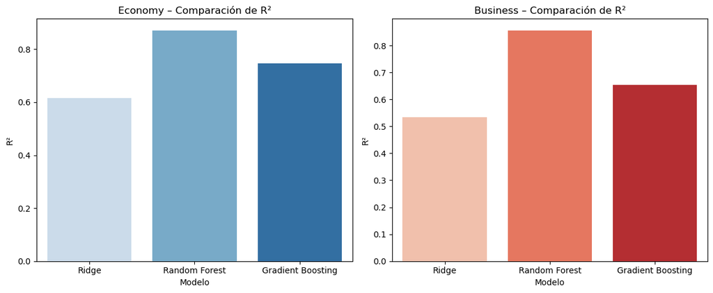

```python
fig, axes = plt.subplots(1, 2, figsize=(12, 5))

sns.barplot(x='Modelo', y='R²', hue='Modelo', data=resultados_econ,
            palette='Blues', legend=False, ax=axes[0])
axes[0].set_title('Economy – Comparación de R²')

sns.barplot(x='Modelo', y='R²', hue='Modelo', data=resultados_bus,
            palette='Reds', legend=False, ax=axes[1])
axes[1].set_title('Business – Comparación de R²')

plt.tight_layout()
plt.show()
```

### Observación comparación visual de R²

El siguiente gráfico compara el desempeño de los tres modelos en ambos segmentos (*Economy* y *Business*), utilizando el coeficiente de determinación **R²** como métrica principal.

#### Conclusión

La comparación visual refuerza los resultados numéricos:

- **Random Forest** es el modelo más robusto y generalizable tanto para *Economy* como *Business*, logrando una relación óptima entre precisión y estabilidad.
- Este resultado lo posiciona como **el mejor candidato para su uso en entornos de predicción de precios reales**, donde la interpretabilidad puede equilibrarse con la alta capacidad predictiva.

### Conclusión general del modelado

Los resultados obtenidos confirman que el **Random Forest Regressor** ofrece el mejor rendimiento general en ambos segmentos.  
Su capacidad para capturar **relaciones no lineales** y manejar **interacciones complejas entre variables** le permite superar ampliamente a los modelos lineales y a otros ensambles más sensibles a la configuración de hiperparámetros.

En consecuencia, **Random Forest se consolida como el modelo base recomendado** para futuras iteraciones del proyecto, tanto por su precisión como por su estabilidad frente a variaciones en los datos.

## 6. Resultados

### 6.1 Síntesis general

El análisis predictivo permitió construir modelos capaces de **estimar el precio de los vuelos** con buena precisión, diferenciando entre los segmentos *Economy* y *Business*.  
El modelo **Random Forest Regressor** demostró el mejor desempeño en ambos casos, alcanzando un **R² superior al 0.85**, lo que indica una excelente capacidad explicativa.

| Segmento | MAE (Error Absoluto Medio) | RMSE (Error Cuadrático Medio) | R² |
| --- | --- | --- | --- |
| Economy | 586 | 1110 | 0.87 |
| Business | 2550 | 4783 | 0.86 |

### 6.2 Interpretación de los resultados

- En el segmento **Economy**, el modelo logra predecir precios con un **error promedio inferior a 600 unidades monetarias**, lo cual representa una precisión elevada considerando la variabilidad del mercado aéreo.
- En **Business**, aunque el error absoluto es mayor (debido a los precios más altos y dispersos), el nivel de ajuste sigue siendo sólido, manteniendo una proporción explicada similar.

### 6.3 Implicaciones de negocio

- Las aerolíneas o agencias de viajes podrían **anticipar variaciones de precios** según temporada, ruta y tipo de servicio, optimizando sus estrategias de oferta.
- Los clientes, por su parte, podrían beneficiarse mediante **sistemas de recomendación o alertas de precios**, basados en predicciones ajustadas a sus rutas e historial de búsqueda.
- A nivel operativo, este tipo de modelo puede integrarse en plataformas de revenue management para **mejorar la planificación de precios dinámicos**.

### 6.4 Próximos pasos

Para fortalecer la precisión y escalabilidad del modelo, se recomienda:

- Experimentar con técnicas de **optimización de hiperparámetros** (GridSearchCV, Optuna, etc.).
- Incorporar nuevas variables (por ejemplo, tipo de avión, duración del vuelo real, o festivos).
- Evaluar modelos más avanzados como **XGBoost o LightGBM**, que podrían ofrecer mejoras marginales en rendimiento.

### Conclusión general

El estudio demuestra que, con una adecuada ingeniería de características y un modelo de ensamble bien configurado, es posible **predecir con alta fiabilidad los precios de vuelos comerciales**.  
Esto sienta las bases para **aplicaciones reales de inteligencia predictiva** en la industria aérea, orientadas tanto a la **eficiencia comercial** como a la **experiencia del cliente**.

## 7. Conclusiones y próximos pasos

### 7.1 Conclusiones generales

El proyecto logró construir un pipeline completo de **Machine Learning aplicado a la predicción de precios de vuelos**, desde la exploración de datos hasta la validación de modelos.  
El análisis evidenció que:

### 7.2 Aprendizajes clave

Este proyecto reafirma la importancia de:

- Aplicar una **limpieza exhaustiva y consistente** en los datos antes del modelado.
- **Equilibrar interpretabilidad y desempeño**, eligiendo modelos que entreguen valor técnico y utilidad de negocio.
- Diseñar notebooks con una **estructura reproducible y documentada**, facilitando su despliegue en entornos colaborativos como GitHub o Kaggle.

### 7.3 Próximos pasos

- Implementar una fase de **tuning automático de hiperparámetros** para optimizar los modelos de ensamble.
- Evaluar la integración de algoritmos más avanzados como **XGBoost, LightGBM o CatBoost**.
- Desarrollar un **dashboard interactivo** o **API de predicción** que permita consultar precios estimados en tiempo real.
- Analizar nuevas fuentes de información (clima, demanda histórica, eventos especiales) para enriquecer las variables predictoras.

### Conclusión final

Este trabajo demuestra cómo la **ciencia de datos puede aportar valor tangible** a la industria aérea, transformando grandes volúmenes de datos en conocimiento accionable.  
El modelo obtenido no solo predice con precisión, sino que también puede servir como base para **sistemas de recomendación, fijación dinámica de precios o herramientas de análisis de mercado**, fortaleciendo la toma de decisiones estratégicas en entornos reales.

## 8. Créditos y tecnologías utilizadas

### 8.1 Autoría

Proyecto desarrollado como parte de un proceso de consolidación de portafolio profesional en **Data Science aplicada al análisis predictivo y a la gestión de recursos**.  
Combina aspectos técnicos de modelado con una orientación clara hacia la **interpretación de resultados y su aplicación en contextos reales de negocio y sostenibilidad**.

### 8.2 Tecnologías y librerías principales

[output not shown]

### 8.3 Estructura del proyecto

El notebook sigue una estructura modular y reproducible:

1. **Contexto y objetivo del análisis**
2. **Carga y preparación de datos**
3. **EDA (análisis exploratorio univariado y bivariado)**
4. **Ingeniería de características y preprocesamiento**
5. **Modelado y validación supervisada**
6. **Resultados e interpretación**
7. **Conclusiones y próximos pasos**
8. **Créditos y tecnologías utilizadas**

### 8.4 Reflexión final

Este proyecto representa una **implementación integral de Data Science aplicada**, uniendo los principios analíticos con la perspectiva científica adquirida en biología e ingeniería en recursos naturales.  
Cada paso —desde la limpieza de datos hasta la validación del modelo— demuestra un enfoque **sistemático, transparente y orientado al aprendizaje continuo**.